# The Importance of Analyzing Seattle’s Temperature Data

Emily Piette

12/16/2019

# The Importance of Analyzing Temperature Data

Seattle’s population has experienced rapid growth, increasing from 150 people in 1860 to 596,101 in 2003 (Conner 2006). With this rapid increase in population, the city’s infrastructure also expanded with the creation of downtown Seattle, leading the city to establish its Weather Bureau. The Weather Bureau moved weather observations in Washington state to Seattle from Olympia, the state’s capitol. NOAA data for Seattle begins in 1894, when a weather station was securely established in Seattle. NOAA refers to this station as “Seattle, Portage Bay,” which actually encompasses five stations in the Portage Bay Area of downtown Seattle involved in data collection. Since weather collection was done on the rooftops of these stations, each time a taller building was built near a station, the station had to move. Due to this happening frequently as the city’s population grew, NOAA moved the weather station for the region to the Seattle Tacoma International Airport in 1944. The station has remained there since (Conner 2006).

Standardization of weather data is important in preventing warming or cooling biases. A study compared regional temperature means provided by inhomogeneous data and homogenous data adjusted through statistical analysis in certain parts of Europe. This study examined data in Europe because Europe has Early Instrumental Period (EIP) data. EIP data extends earlier than the 1850s, which marks the onset of industrialization and increase in fossil fuel emissions. The mid 19th century was also marks a cold period where one of the largest glacier extensions of the past 10,000 years occurred. This study shows data extending back before the 1850s is useful in eliminating warming bias from present weather data, as it adjusted temperature data throughout Europe, redetermining which years were coolest and warmest, and how these years impacted mean temperature increases and decreases for this region (Böhm et Al 2009).

Another study compared data from the USHCN with data from the USCRN. The USHCN is the U.S. Historical Climatological Network, including 1218 stations, with the goal of producing long, continuous temperature records to accurately reflect temperature means for regions across the United States. The USHCN’s data was problematized by time of observation changes, instrument changes, station location changes, and changes in population growth of surrounding locations, leading to USHCN data becoming inhomogeneous and subject to public and political scrutiny (Hausfather et al 2006). Due to issues with the USHCN, NOAA set up the set up USCRN in 2001. USCRN stations include improved instruments, constant monitoring by staff, and are located in rural environments removed from urban influence. The new U.S. Climate Reference Network (USCRN) provides a homogenous set of surface temperature observations which this study compared to potentially biased data from USHCN stations when the networks overlapped between 2004-2015 (Hausfather et al 2006). The study separately performs the analysis for minimum (tmin ), maximum (tmax ), and average (tavg) monthly temperatures, checking if NOAA’s homogenization algorithm effectively removes inhomogeneities in the temperature trend without introducing more biases (Hausfather et al 2006).

These studies show bias in data is mediated through statistical analysis, which is a necessary precaution researchers must take when examining temperature data, as arguments asserting trends of global warming or cooling can discredited if they are based on inhomogenous data. These arguments are examples of the “jumping to conclusions” logical fallacy, as they make claims ignoring potential biases.

This blog explores how Seattle’s early weather data can be incorporated into the Seatac temperature data set, providing Seattle with long term temperature data. Credible, long term temperature data informs future temperature predictions for the region, which is important because warmer temperatures in Seattle will impact the regions larger climate significantly. A study by the University of Washington Climate impacts group shows Seattle has averaged only a handful of 90°F days per year during the past few decades, but by 2100, more than two weeks of 90°F days will likely occur each summer. Increased temperatures will likely increase water demand, impacting water management in Seattle (Bumbaco et Al 2013). Rising temperatures will also impact sea level rise in the region. A study found that while in some parts of Washington the land is uplifting, counterbalancing sea level rise, Seattle is sinking with the rise of Puget Sound waters. If temperatures keep rising at the same rate, Seattle will see a 2-3 feet sea level rise by 2100. Sea level rise of this magnitude will require Seattle city planners to make significant adjustments to the city’s infrastructure, displacing many residents and businesses (Miller et Al 2018). This blog demonstrates how temperature data suggests the threats of sea level and temperature rise in Seattle should be taken seriously, exploring whether the many changes to Seattle’s weather station impact Seattle’s weather data or not. Data was obtained from NOAA curated temperature and precipitation records from Seattle, Portage Bay (Station ID: 024281) and from 1894-1944 and Seattle Tacoma International Airport (Station ID: 024233) from 1944-present, and processed in the R programming environment (CRAN 2019).

# Obtaining and Analyzing 125 years of Seattle Weather Data

## Plot

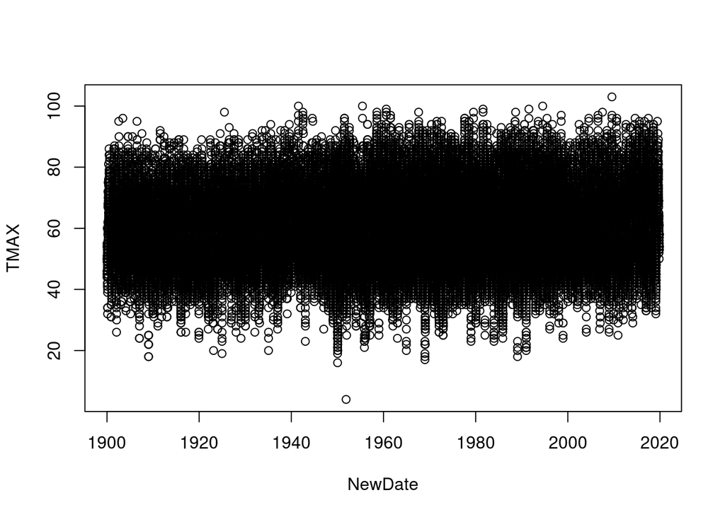

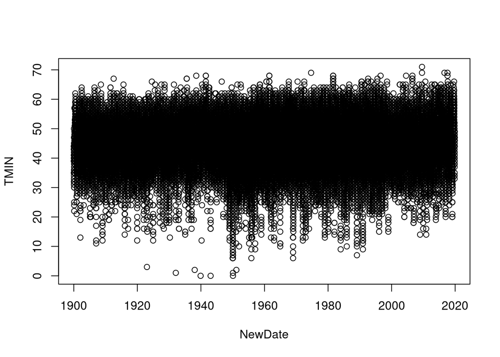

## Creating Monthly Means

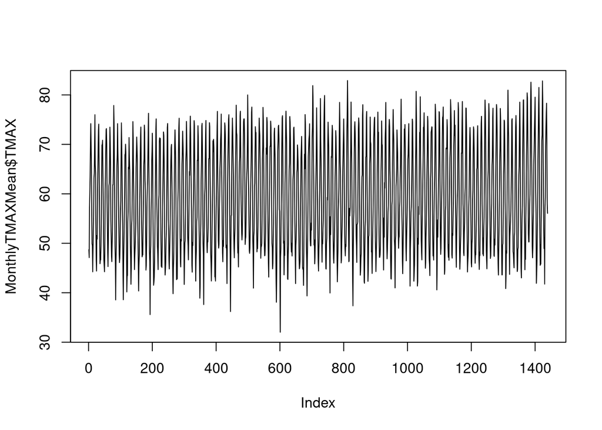

## Selecting for One Month (May)

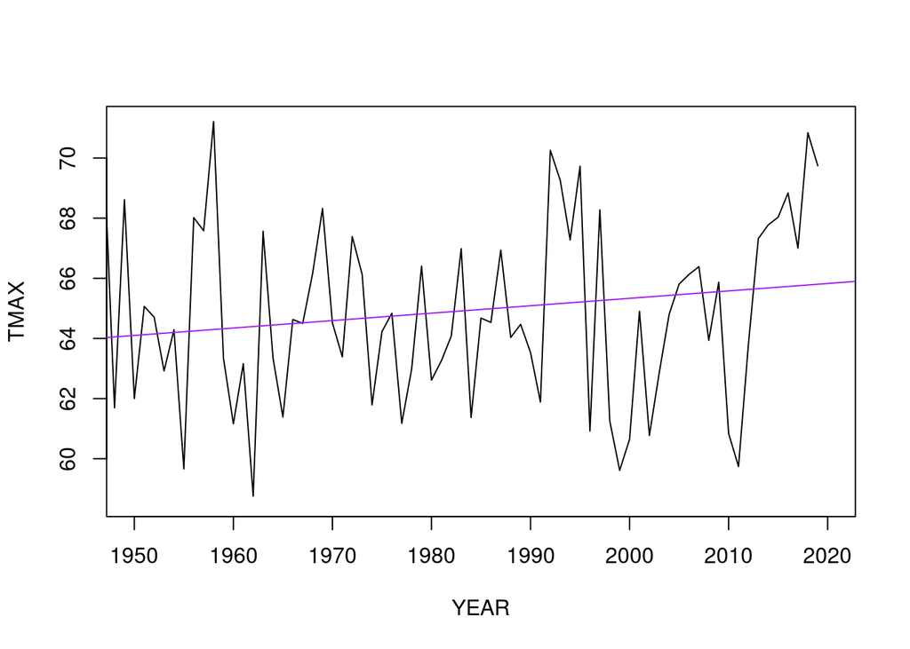

## Testing All the Months

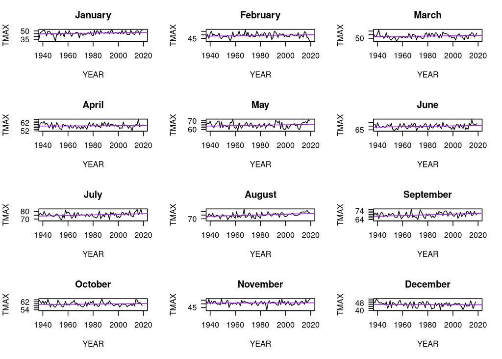

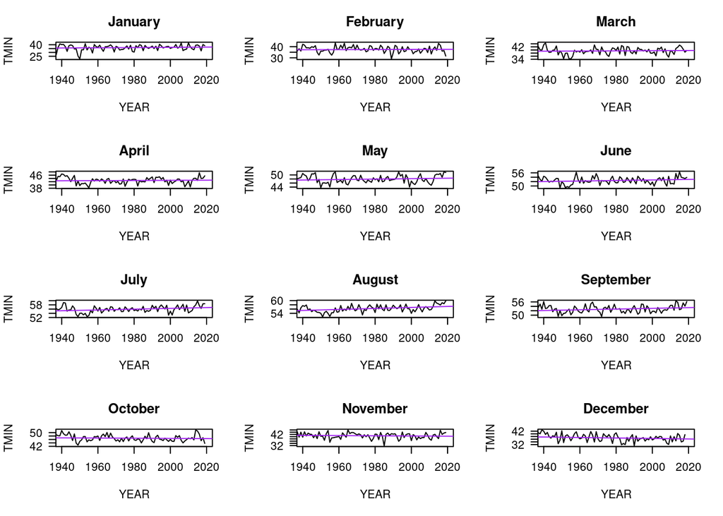

## Analyzing Minimum Daily Temperatures

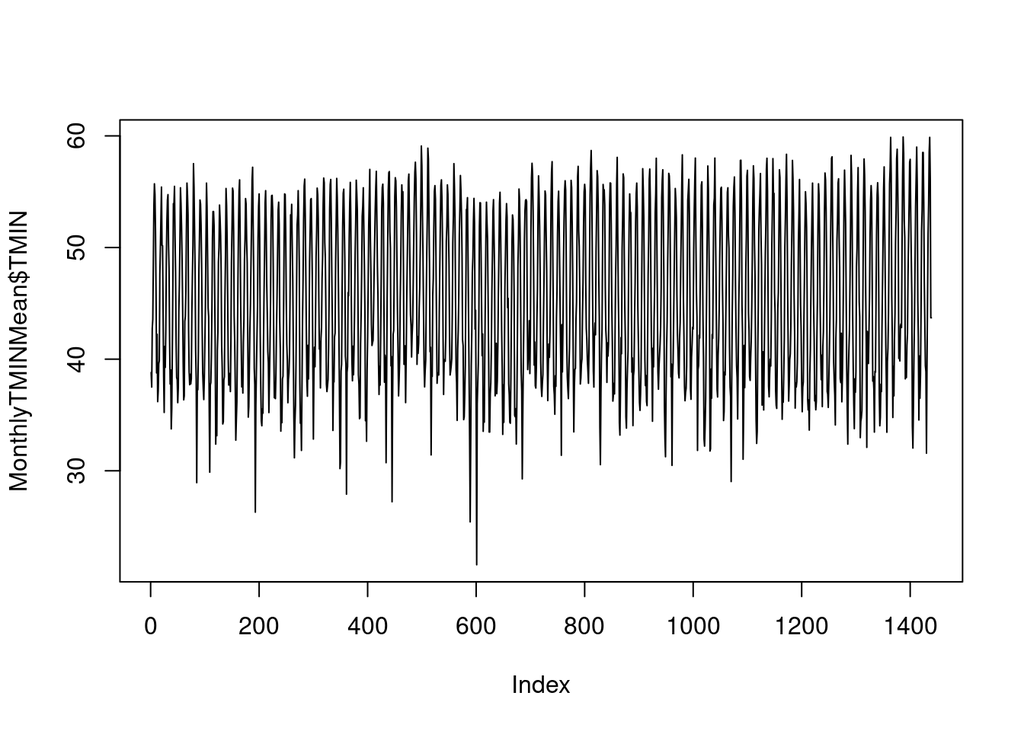

## Remove and Plot Missing Precipitation Values

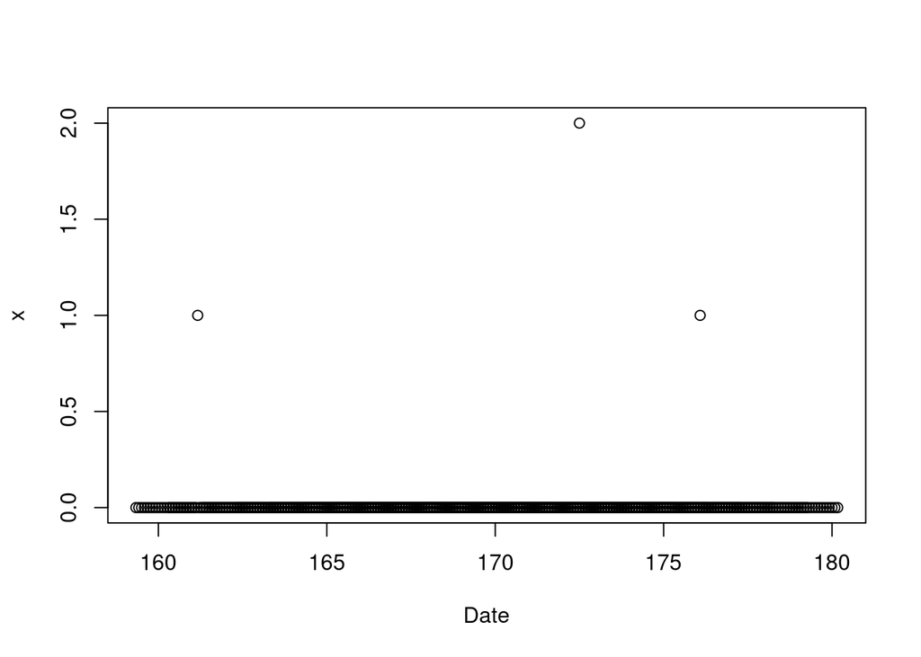

## Decide Level of Aggredation (aggreate to get by month and year to get monthy totals)

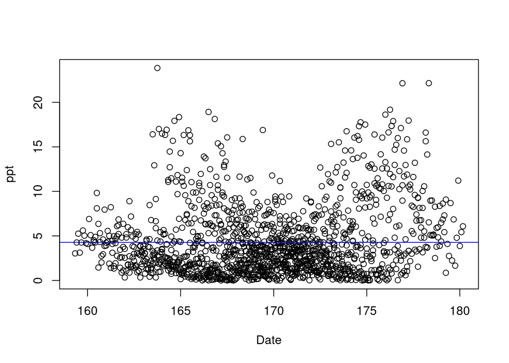

## Model Diagnostics

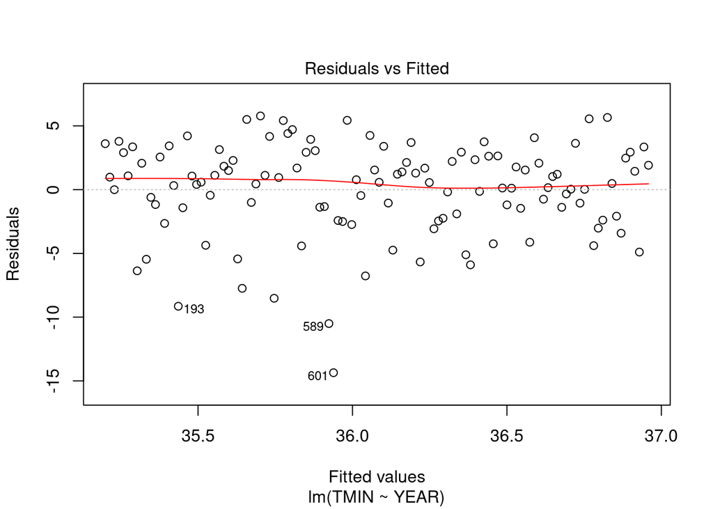

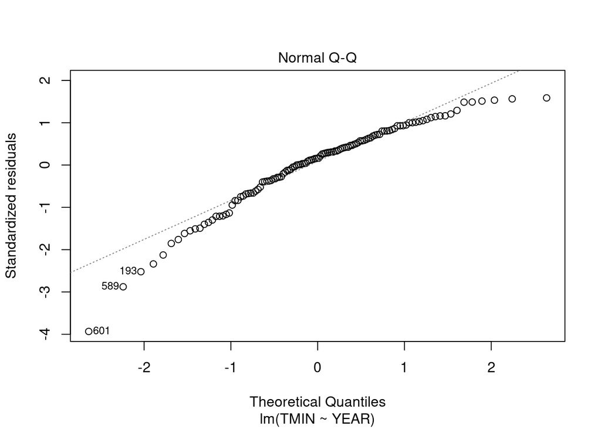

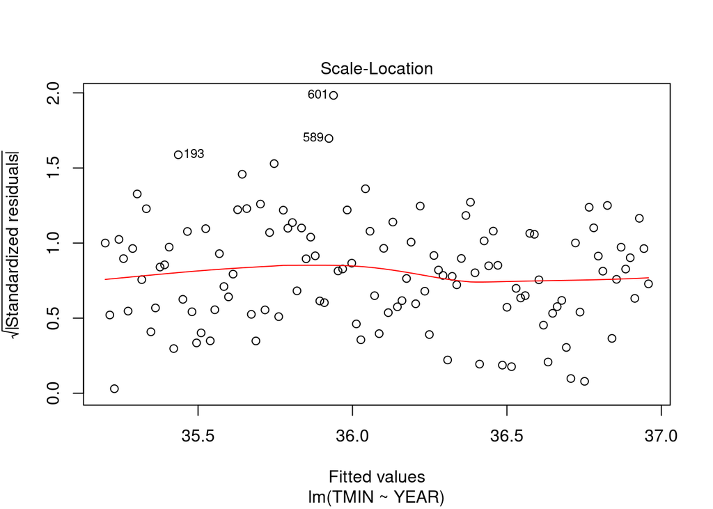

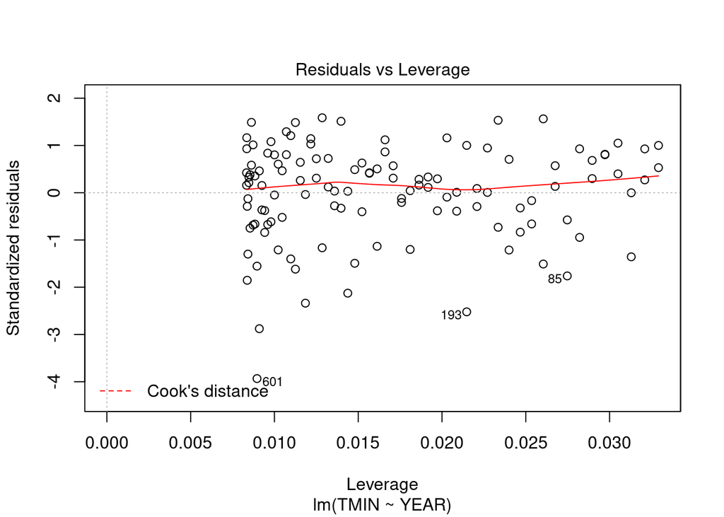

# Analyzing 125 Years of Seattle Temperature Data

## Histogram 1

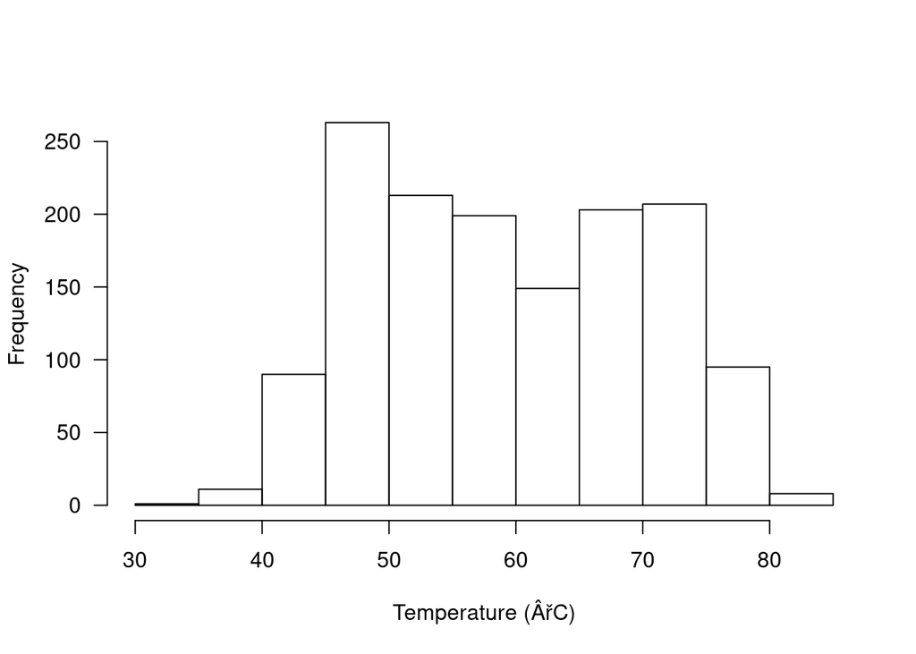

## Histogram 2

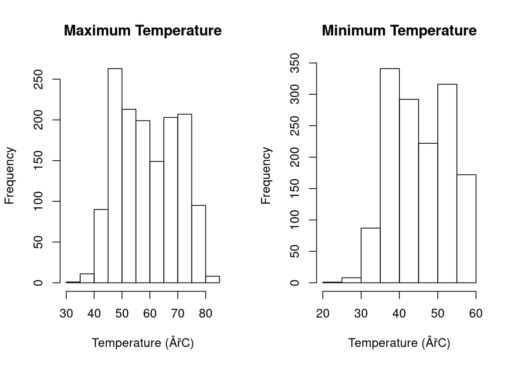

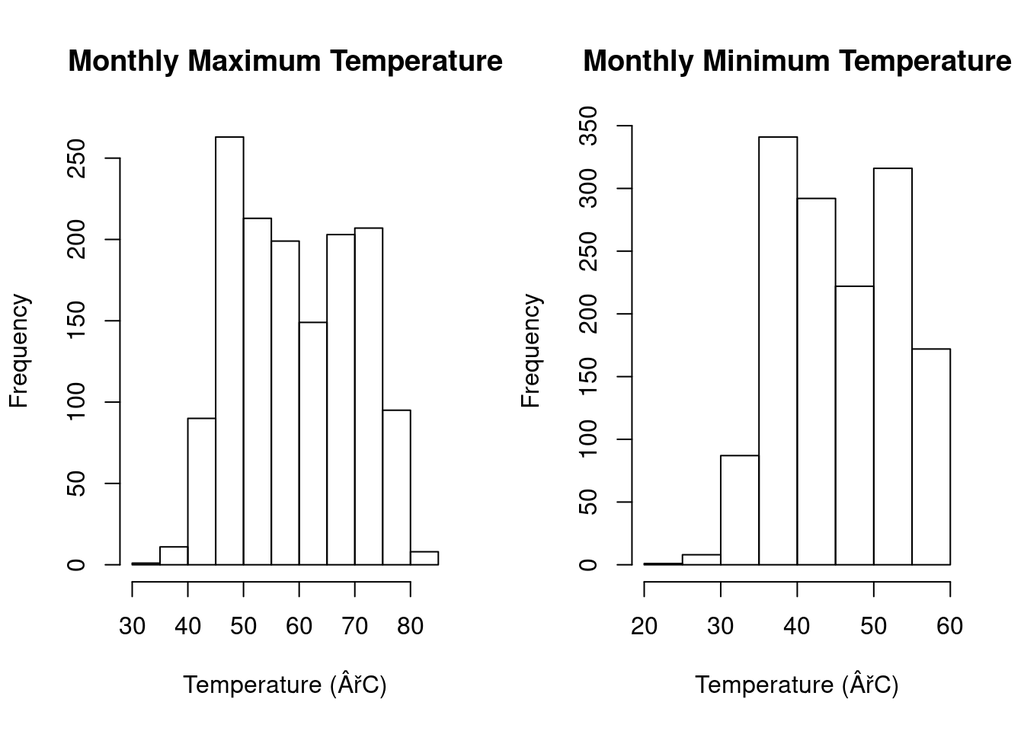

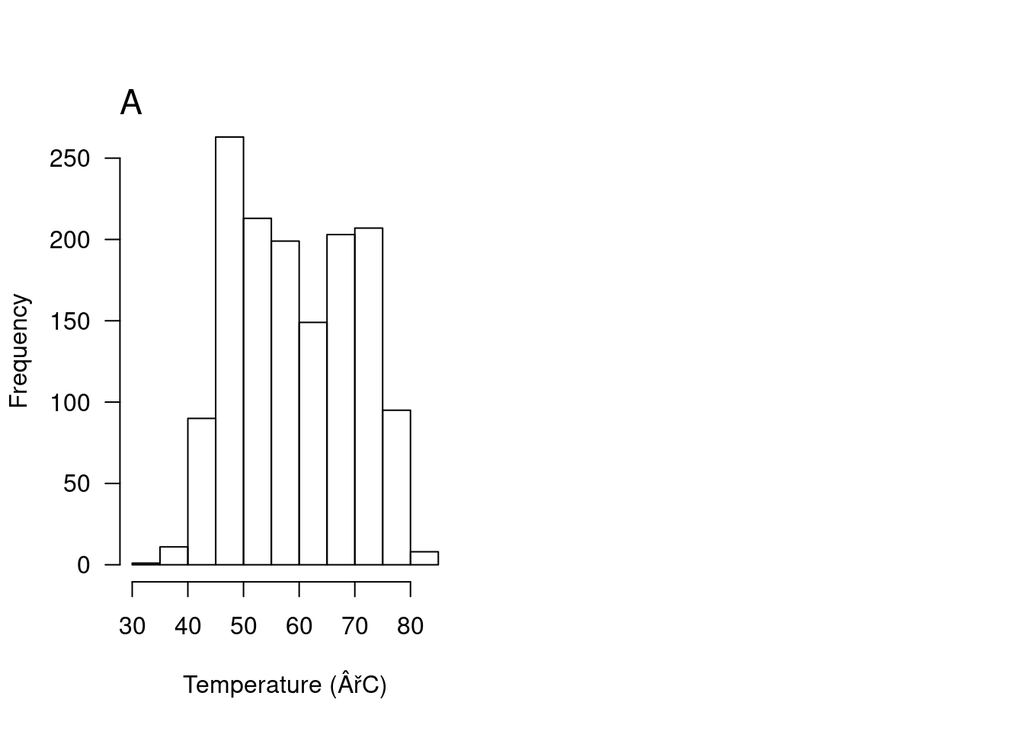

# Scatter Plot

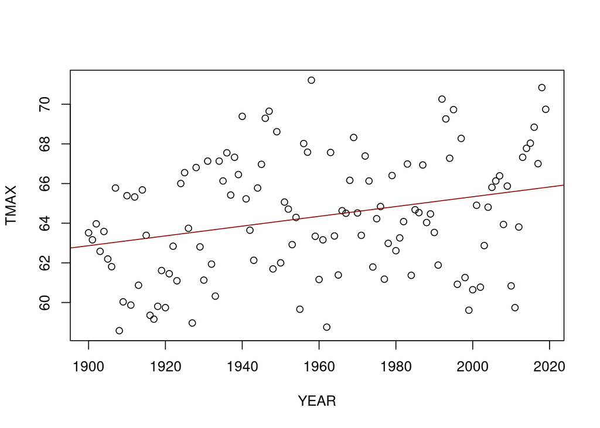

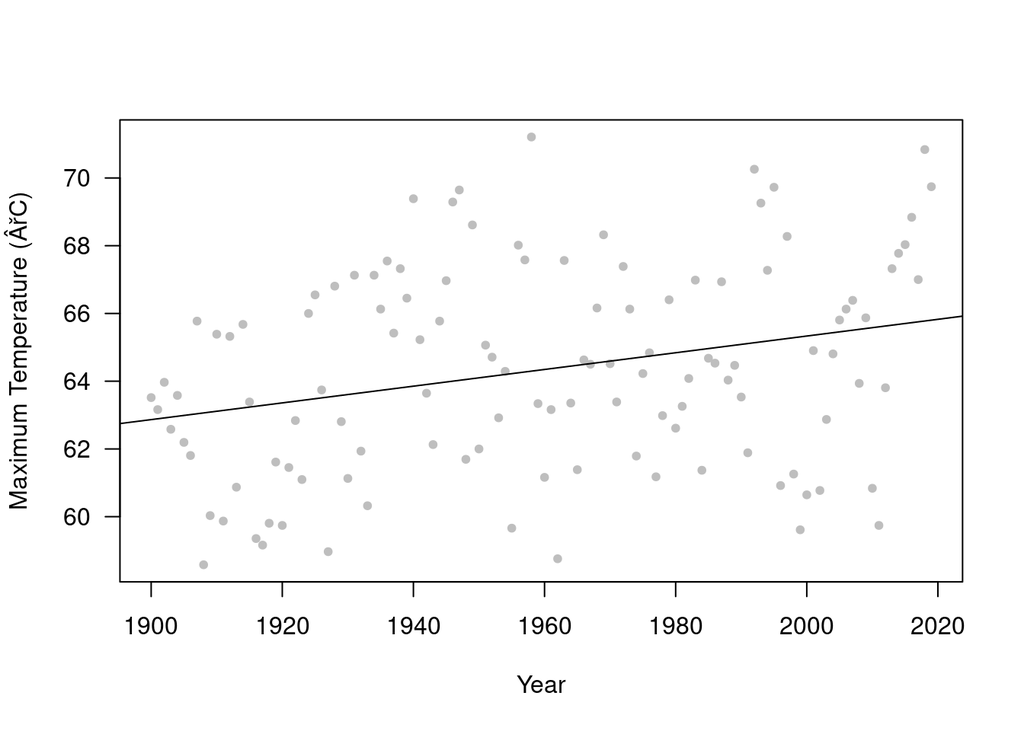

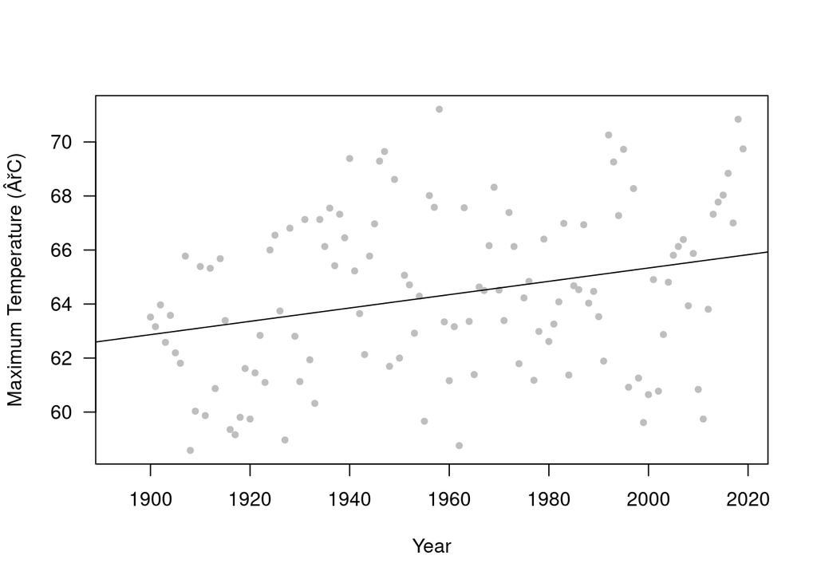

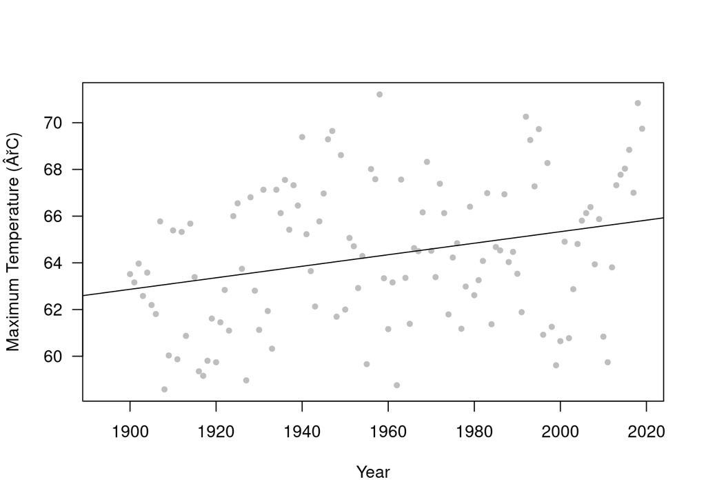

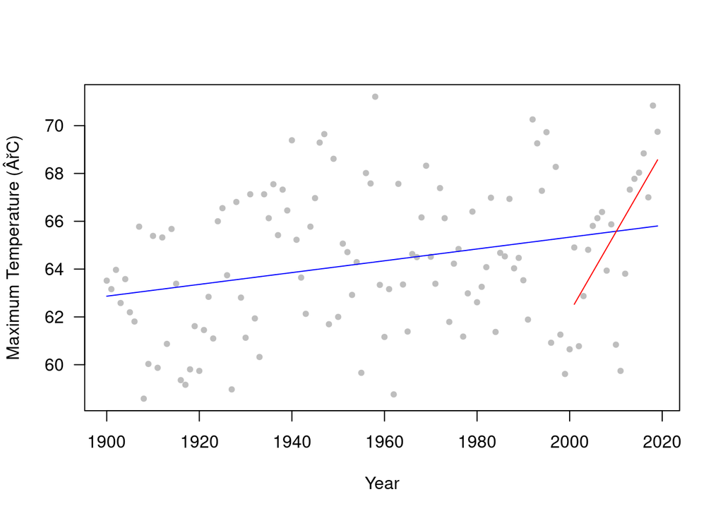